# TITANIC dataset exploration - who survived?

[figure not shown]

Willy Stöwer, died on 31st May 1931 — Magazine Die Gartenlaube

- Dataset description and first set of questions
- Project set-up
- Data acquisition
- Data check
- Data cleaning
- Data exploration
- Data prediction
- Conclusion

## Dataset description and first set of questions

The description of the dataset and its parameters are available at: https://www.kaggle.com/c/titanic

Some simple questions raise first:

- what kind of people travelled on giant boats early last century?
- among the recorded passengers, how many survived?
- which country was the most affected?
- is there a category of passenger more represented in survivors population?
- in other terms, are there some parameters acting on survival chances?

Some questions of second order:

- what was the price of a Titanic ticket depending of the departure place?

Some questions a bit more complex:

- is the location of the cabin within the Titanic a driving factor?
- what can we extract from social conditions (age, family, budget...)

## Project set-up

let's import necessary modules

```python
import os, re
import numpy as np
import pandas as pd
import matplotlib.pyplot as plt
import seaborn as sb
```

some notebook-related configuration...

```python
%matplotlib inline
sb.set_context("notebook", font_scale=1.25)
```

collecting project input

```python
titanic_folder   = os.path.join('..', 'projects', 'titanic')
titanic_filename = 'titanic-data.csv'
titanic_file     = os.path.join(titanic_folder, titanic_filename)
assert os.path.exists(titanic_file)
```

## Data acquisition

loading the input dataset as DataFrame

```python
titanic_df = pd.read_csv(titanic_file)
```

first sight at available columns

```python
titanic_df.head()
```

|  | PassengerId | Survived | Pclass | Name | Sex | Age | SibSp | Parch | Ticket | Fare | Cabin | Embarked |
| --- | --- | --- | --- | --- | --- | --- | --- | --- | --- | --- | --- | --- |
| 0 | 1 | 0 | 3 | Braund, Mr. Owen Harris | male | 22.0 | 1 | 0 | A/5 21171 | 7.2500 | NaN | S |
| 1 | 2 | 1 | 1 | Cumings, Mrs. John Bradley (Florence Briggs Th... | female | 38.0 | 1 | 0 | PC 17599 | 71.2833 | C85 | C |
| 2 | 3 | 1 | 3 | Heikkinen, Miss. Laina | female | 26.0 | 0 | 0 | STON/O2. 3101282 | 7.9250 | NaN | S |
| 3 | 4 | 1 | 1 | Futrelle, Mrs. Jacques Heath (Lily May Peel) | female | 35.0 | 1 | 0 | 113803 | 53.1000 | C123 | S |
| 4 | 5 | 0 | 3 | Allen, Mr. William Henry | male | 35.0 | 0 | 0 | 373450 | 8.0500 | NaN | S |

now let's jump into the dataset for a wrangling session

```python
titanic_df.shape
```

```
(891, 12)
```

891 passengers data have been collected, each with 12 columns

```python
titanic_df.columns
```

```
Index([u'PassengerId', u'Survived', u'Pclass', u'Name', u'Sex', u'Age',
       u'SibSp', u'Parch', u'Ticket', u'Fare', u'Cabin', u'Embarked'],
      dtype='object')
```

## Data check

check that each passenger is unique

```python
titanic_df['PassengerId'].unique().size == titanic_df.shape[0]
```

```
True
```

check that only two values are available for 'Survived' column

```python
titanic_df.groupby('Survived').groups.keys() # display available values
```

```
[0, 1]
```

get number of cabin class levels

```python
titanic_df.groupby('Pclass').groups.keys() # display available values
```

```
[1, 2, 3]
```

check that names are string

```python
for name in titanic_df['Name']:
    if type(name) != str: print name
```

names entries seem ok

check gender entries

```python
titanic_df.groupby('Sex').groups.keys() # display available values
```

```
['male', 'female']
```

check only positive values for column age

```python
age_issues = True ^ (titanic_df['Age'] > 0.) # look for NaN or negative values
titanic_df[age_issues].head()
```

|  | PassengerId | Survived | Pclass | Name | Sex | Age | SibSp | Parch | Ticket | Fare | Cabin | Embarked |
| --- | --- | --- | --- | --- | --- | --- | --- | --- | --- | --- | --- | --- |
| 5 | 6 | 0 | 3 | Moran, Mr. James | male | NaN | 0 | 0 | 330877 | 8.4583 | NaN | Q |
| 17 | 18 | 1 | 2 | Williams, Mr. Charles Eugene | male | NaN | 0 | 0 | 244373 | 13.0000 | NaN | S |
| 19 | 20 | 1 | 3 | Masselmani, Mrs. Fatima | female | NaN | 0 | 0 | 2649 | 7.2250 | NaN | C |
| 26 | 27 | 0 | 3 | Emir, Mr. Farred Chehab | male | NaN | 0 | 0 | 2631 | 7.2250 | NaN | C |
| 28 | 29 | 1 | 3 | O'Dwyer, Miss. Ellen "Nellie" | female | NaN | 0 | 0 | 330959 | 7.8792 | NaN | Q |

*WARNING*: some passenger ages are unknown and got a NaN value in the dataset, grouping these passengers

```python
without_age_index = titanic_df[age_issues].index
```

```python
without_age_index
```

```
Int64Index([  5,  17,  19,  26,  28,  29,  31,  32,  36,  42,
            ...
            832, 837, 839, 846, 849, 859, 863, 868, 878, 888],
           dtype='int64', length=177)
```

177 of 891 passengers have a NaN instead of their age

number of other passengers of same family and generation (sibling or spouse):

```python
np.where(True ^ (titanic_df['SibSp']>=0)) # look for NaN or negative values
```

```
(array([], dtype=int64),)
```

```python
titanic_df.groupby('SibSp').groups.keys() # display possible values
```

```
[0, 1, 2, 3, 4, 5, 8]
```

A maximum of 8 siblings! It means that at least 9 passengers should have 8 brothers or sisters, let's find them

```python
titanic_df.groupby('SibSp').groups[8].size
```

```
7
```

They are only 7 passengers with 8 brothers or sisters, some of them must be missing in the dataset records...

number of other passengers of same family and previous or next generation (children or parent):

```python
titanic_df.groupby('Parch').groups.keys() # display available values
```

```
[0, 1, 2, 3, 4, 5, 6]
```

```python
np.where(True ^ (titanic_df['Parch']>=0)) # check negative or NaN values
```

```
(array([], dtype=int64),)
```

no issue with Parch parameter

checking Ticket parameter, seems to be an integer:

```python
def str2int(ticket_string):
    try:
        return int(ticket_string)
    except:
        return np.nan
```

Let's see which fields failed while converted into integers

```python
non_integer_tickets = titanic_df['Ticket'][np.isnan(titanic_df['Ticket'].apply(str2int))]
print non_integer_tickets.head()
print non_integer_tickets.size
```

```
0            A/5 21171
1             PC 17599
2     STON/O2. 3101282
10             PP 9549
12           A/5. 2151
Name: Ticket, dtype: object
230
```

230 tickets entries seem to not correspond to an integer, since including characters corresponding to place of ticklet purchase

checking Fare parameter:

```python
titanic_df['Fare'].describe()
```

```
count    891.000000
mean      32.204208
std       49.693429
min        0.000000
25%        7.910400
50%       14.454200
75%       31.000000
max      512.329200
Name: Fare, dtype: float64
```

checking Cabin parameter:

```python
titanic_df.groupby('Cabin').groups.keys()[:20]
```

```
['E36',
 'D17',
 'D50',
 'E77',
 'C30',
 'D56',
 'C32',
 'G6',
 'B50',
 'C62 C64',
 'D',
 'B102',
 'B101',
 'E68',
 'F33',
 'T',
 'F38',
 'A24',
 'E63',
 'E67']
```

*WARNING*: some passengers have several cabins

## Data cleaning

The parameter "Cabin" seems not easy to handle, would be great to convert it to the number of cabins linked to a single given passenger, and the deck number where the cabins stand

Let's build some functions that convert the cabin parameter into new parameters 'ncabins' and 'deck' accepts only cabin names with pattern "one letter + several digits"

```python
# check that cabin description is exploitable, with pattern B25, Z3 or T
def is_cabin(cabin_str):
    # at least one letter, 0 or N numbers
    if re.match(r'[aA-zZ]{1}[0-9]*', cabin_str.strip()):
        return True
    else:
        return False

# extract list of strings inside cabin_field
def extract_cabin_list(cabin_field):
    if isinstance(cabin_field, str):
        candidate_cabins = re.split(r'[ ,;-]', cabin_field)
        cabin_list = list(filter(is_cabin, candidate_cabins))
        return cabin_list
    else:
        return list()

def count_cabins(cabin_field):
    cabin_list = extract_cabin_list(cabin_field)
    return len(cabin_list)

def extract_deck(cabin_field):
    cabin_list = extract_cabin_list(cabin_field)
    deck_level = np.nan
    for cabin in cabin_list:
        if re.match(r'[aA-zZ]{1}[0-9]*', cabin.strip()):
            # overwriting deck value if available (assuming that cabins share the same deck)
            deck_letter = re.sub(r'([aA-zZ]{1})[0-9]*', r'\1', cabin.strip())
            # converting 'A' to 0, 'B' to 1, etc.
            deck_level = int(ord(deck_letter) - 65)
    return deck_level
```

testing the function:

```python
print count_cabins('A13 b456, Z5')
print extract_deck('A1 A2, A3'), extract_deck('C23'),
```

```
3
0 2
```

Applying this convert function to the column "Cabin" and create the new columns "nbCabins" and "deck"

```python
titanic_df['nbCabins'] = titanic_df['Cabin'].apply(count_cabins)
titanic_df['deck']     = titanic_df['Cabin'].apply(extract_deck)
```

checking the passenger with max number of cabins

```python
print titanic_df['nbCabins'].max()
print titanic_df['Cabin'].iloc[titanic_df['nbCabins'].argmax()]
```

```
4
B57 B59 B63 B66
```

let's have a look on raw statistics on the dataset:

```python
titanic_df.describe()
```

|  | PassengerId | Survived | Pclass | Age | SibSp | Parch | Fare | nbCabins | deck |
| --- | --- | --- | --- | --- | --- | --- | --- | --- | --- |
| count | 891.000000 | 891.000000 | 891.000000 | 714.000000 | 891.000000 | 891.000000 | 891.000000 | 891.000000 | 204.000000 |
| mean | 446.000000 | 0.383838 | 2.308642 | 29.699118 | 0.523008 | 0.381594 | 32.204208 | 0.267116 | 2.460784 |
| std | 257.353842 | 0.486592 | 0.836071 | 14.526497 | 1.102743 | 0.806057 | 49.693429 | 0.547134 | 1.871074 |
| min | 1.000000 | 0.000000 | 1.000000 | 0.420000 | 0.000000 | 0.000000 | 0.000000 | 0.000000 | 0.000000 |
| 25% | 223.500000 | 0.000000 | 2.000000 | 20.125000 | 0.000000 | 0.000000 | 7.910400 | 0.000000 | 1.000000 |
| 50% | 446.000000 | 0.000000 | 3.000000 | 28.000000 | 0.000000 | 0.000000 | 14.454200 | 0.000000 | 2.000000 |
| 75% | 668.500000 | 1.000000 | 3.000000 | 38.000000 | 1.000000 | 0.000000 | 31.000000 | 0.000000 | 3.000000 |
| max | 891.000000 | 1.000000 | 3.000000 | 80.000000 | 8.000000 | 6.000000 | 512.329200 | 4.000000 | 19.000000 |

The statistics "count" seems a convenient way to detect the NaN values, since we concluded previously that only 714 passengers had their age collected in the dataset. Let's see the other columns:

```python
titanic_df.count()
```

```
PassengerId    891
Survived       891
Pclass         891
Name           891
Sex            891
Age            714
SibSp          891
Parch          891
Ticket         891
Fare           891
Cabin          204
Embarked       889
nbCabins       891
deck           204
dtype: int64
```

Only three columns deviate from number of passengers (or have missing values): Age, Cabin, Embarked. The two first have already been analyzed, let's focus on Embarked for which 2 values seem missing:

```python
titanic_df.groupby('Embarked').groups.keys()
```

```
['Q', 'C', 'S']
```

The values found within dataset matches with the description in kaggle website: C = Cherbourg, Q = Queenstown, S = Southampton

```python
missing_bools = True ^ ((titanic_df['Embarked'] == 'Q') | (titanic_df['Embarked'] == 'C') | (titanic_df['Embarked'] == 'S'))
titanic_df[missing_bools]
```

|  | PassengerId | Survived | Pclass | Name | Sex | Age | SibSp | Parch | Ticket | Fare | Cabin | Embarked | nbCabins | deck |
| --- | --- | --- | --- | --- | --- | --- | --- | --- | --- | --- | --- | --- | --- | --- |
| 61 | 62 | 1 | 1 | Icard, Miss. Amelie | female | 38.0 | 0 | 0 | 113572 | 80.0 | B28 | NaN | 1 | 1.0 |
| 829 | 830 | 1 | 1 | Stone, Mrs. George Nelson (Martha Evelyn) | female | 62.0 | 0 | 0 | 113572 | 80.0 | B28 | NaN | 1 | 1.0 |

Once again, the missing values are NaN, corresponding to passengers who booked the same cabin. Since both passengers survived, let's assume that they simply did not embark on the Titanic, lucky guys! To make it fun, let's try later to predict their chance to survive if they could embark.

### The dataset seems clean enough to start exploration!

## Data exploration

Let's try to refine and answer some of the questions raised at the beginning of the project:

- among the recorded passengers, how many survived?
- which country was the most affected?
- is there a category of passenger more represented in survivors population?
- in other terms, are there some parameters acting on survival chances? such as deck level?
- what was the price of a Titanic ticket depending of the departure place and the cabin class level?
- is the location of the cabin within the Titanic a driving factor?
- what can we extract from social conditions (age, family, budget...)

### survival rate

First obvious question: how many people did survive?

```python
print titanic_df['Survived'].sum(), titanic_df['Survived'].mean()
```

```
342 0.383838383838
```

342 of 891 passengers were rescued, which gives a rate of only 38% !

### country

```python
titanic_df.groupby('Embarked')['PassengerId'].count()
```

```
Embarked
C    168
Q     77
S    644
Name: PassengerId, dtype: int64
```

The distribution over counties of boarding is not homogeneous at all, is it the same for survival rate? Let's answer with a graph:

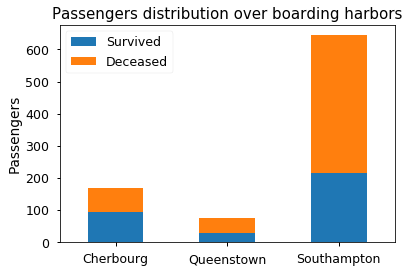

```python
by_country_survived = titanic_df[titanic_df['Survived']==1].groupby('Embarked')['PassengerId'].count()
by_country_deceased = titanic_df[titanic_df['Survived']==0].groupby('Embarked')['PassengerId'].count()
plot_df = pd.concat([by_country_survived, by_country_deceased], axis=1)
plot_df.columns=['Survived', 'Deceased']
ax = plot_df.plot.bar(stacked=True, rot=0)
ax.set_xticklabels(('Cherbourg','Queenstown','Southampton'))
ax.set_xlabel('')
ax.set_ylabel('Passengers')
t = ax.set_title('Passengers distribution over boarding harbors')
```

The survival rate seem unequal pending the country of boarding!

### cabin fare

What was the price of a Titanic ticket depending of the departure place and the cabin class level? Since a given passenger may have paid several cabins, we should first compute the price per cabin

```python
titanic_df['cabinFare'] = titanic_df['Fare'].div(titanic_df['nbCabins'])
# division by zero cabins leads to infinite value, replacing by NaN
titanic_df['cabinFare'].replace(np.inf, np.nan, inplace=True)
```

```python
titanic_df['cabinFare'].describe()
```

```
count    204.000000
mean      64.561486
std       54.980588
min        0.000000
25%       29.453125
50%       54.050000
75%       83.158300
max      512.329200
Name: cabinFare, dtype: float64
```

Min value seems a bit strange, were some passengers with cabins invited by the Titanic company? Or are they from the crew?

```python
titanic_df[(titanic_df['Fare']==0) & (titanic_df['cabinFare']==0)]
titanic_df[titanic_df['cabinFare']==0]
```

|  | PassengerId | Survived | Pclass | Name | Sex | Age | SibSp | Parch | Ticket | Fare | Cabin | Embarked | nbCabins | deck | cabinFare |
| --- | --- | --- | --- | --- | --- | --- | --- | --- | --- | --- | --- | --- | --- | --- | --- |
| 263 | 264 | 0 | 1 | Harrison, Mr. William | male | 40.0 | 0 | 0 | 112059 | 0.0 | B94 | S | 1 | 1.0 | 0.0 |
| 806 | 807 | 0 | 1 | Andrews, Mr. Thomas Jr | male | 39.0 | 0 | 0 | 112050 | 0.0 | A36 | S | 1 | 0.0 | 0.0 |
| 815 | 816 | 0 | 1 | Fry, Mr. Richard | male | NaN | 0 | 0 | 112058 | 0.0 | B102 | S | 1 | 1.0 | 0.0 |

Three people did not pay their ticket! But in the end this was a poisoned gift since none of the three did survive... Now let's focus on paying passengers

```python
paying_df = titanic_df[titanic_df['cabinFare'] > 0.]
print paying_df.index.size
paying_df.head()
```

```
201
```

[output not shown]

Let's analyze the population of 201 paying passengers

Who is the passenger with the most expensive cabin?

```python
paying_df.loc[paying_df['cabinFare'].argmax()]
```

```
PassengerId                       738
Survived                            1
Pclass                              1
Name           Lesurer, Mr. Gustave J
Sex                              male
Age                                35
SibSp                               0
Parch                               0
Ticket                       PC 17755
Fare                          512.329
Cabin                            B101
Embarked                            C
nbCabins                            1
deck                                1
cabinFare                     512.329
Name: 737, dtype: object
```

Gustave Lesurer was a french passenger who embarked in Cherbourg, travelled in a luxurious cabin... and survived. Let's then see if rich passengers were more numerous among survivors:

```python
paying_df.groupby('Survived')['cabinFare'].describe()
```

| Survived | count | mean | std | min | 25% | 50% | 75% | max |
| --- | --- | --- | --- | --- | --- | --- | --- | --- |
| 0 | 65.0 | 55.101377 | 43.690786 | 1.666667 | 27.750 | 40.1250 | 77.2875 | 221.7792 |
| 1 | 136.0 | 70.507013 | 58.900030 | 8.050000 | 30.375 | 58.9896 | 86.5000 | 512.3292 |

The cabin fare mean value of survivors is a bit higher than the one of deceased people, let's plot the cabin fare distribution of both populations

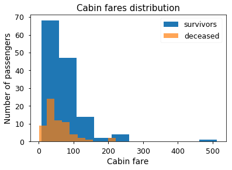

```python
paying_survivors = paying_df[paying_df['Survived']==1]
paying_deceased = paying_df[paying_df['Survived']==0]
paying_survivors['cabinFare'].plot.hist(label='survivors')
paying_deceased['cabinFare'].plot.hist(alpha=0.7,label='deceased')
plt.xlabel('Cabin fare')
plt.ylabel('Number of passengers')
plt.title('Cabin fares distribution')
l = plt.legend()
```

Let's remove the outliers who paid much more than the other passengers, and verify these mean values. The third quartile is around 77\$ whereas the maximum value is over 500\$. Let's remove tickets above 200$

```python
filtered_paying_survivors = paying_survivors[paying_survivors['cabinFare']<200]
filtered_paying_deceased = paying_deceased[paying_deceased['cabinFare']<200]
```

```python
print ('%.0f' % filtered_paying_survivors['cabinFare'].mean())
print ('%.0f' % filtered_paying_deceased['cabinFare'].mean())
```

```
63
50
```

The mean cabin fare of survivors is still about 25% above the mean cabin fare of deceased people, therefore the price of the cabin seems to be some advantaging factor. At this stage, impossible to validate this statement since other factors may be coupled.

Let's check at least that the cabin fare, class level and deck level are well correlated, as expected.

```python
titanic_df.groupby('Pclass')['deck','cabinFare'].mean()
```

| Pclass | deck | cabinFare |
| --- | --- | --- |
| 1 | 2.107955 | 72.521576 |
| 2 | 4.250000 | 18.063544 |
| 3 | 5.250000 | 9.810762 |

Cabin fare, class and deck level seem correlated: the higher the level, the higher the deck, the higher fare.

'Class' parameter or 'deck' are more convenient ways to extract chance to survive than "cabin fare" since data can be easily grouped by these fields which are of type integer. On top of that, extracting mean value of "Survived" field gives direct access to the survival rate of a passenger group since this parameter is a boolean (whose mean is a rate)

### Survival rate vs. cabin class & deck level

We might assume that the deeper the deck the more difficult to evacuate the ship. Let's analyse deck level associated to cabin class parameters.

[figure not shown]

Titanic decks By Anonymous [Public domain]

Let's display the survival rate against class level and deck. 'Count' column gives the number of passengers and 'Mean' the survival rate:

```python
titanic_df.groupby('Pclass')['Survived'].describe()
```

| Pclass | count | mean | std | min | 25% | 50% | 75% | max |
| --- | --- | --- | --- | --- | --- | --- | --- | --- |
| 1 | 216.0 | 0.629630 | 0.484026 | 0.0 | 0.0 | 1.0 | 1.0 | 1.0 |
| 2 | 184.0 | 0.472826 | 0.500623 | 0.0 | 0.0 | 0.0 | 1.0 | 1.0 |
| 3 | 491.0 | 0.242363 | 0.428949 | 0.0 | 0.0 | 0.0 | 0.0 | 1.0 |

```python
titanic_df.groupby('deck')['Survived'].describe()
```

| deck | count | mean | std | min | 25% | 50% | 75% | max |
| --- | --- | --- | --- | --- | --- | --- | --- | --- |
| 0.0 | 15.0 | 0.466667 | 0.516398 | 0.0 | 0.0 | 0.0 | 1.0 | 1.0 |
| 1.0 | 47.0 | 0.744681 | 0.440755 | 0.0 | 0.5 | 1.0 | 1.0 | 1.0 |
| 2.0 | 59.0 | 0.593220 | 0.495450 | 0.0 | 0.0 | 1.0 | 1.0 | 1.0 |
| 3.0 | 33.0 | 0.757576 | 0.435194 | 0.0 | 1.0 | 1.0 | 1.0 | 1.0 |
| 4.0 | 33.0 | 0.757576 | 0.435194 | 0.0 | 1.0 | 1.0 | 1.0 | 1.0 |
| 5.0 | 9.0 | 0.777778 | 0.440959 | 0.0 | 1.0 | 1.0 | 1.0 | 1.0 |
| 6.0 | 7.0 | 0.285714 | 0.487950 | 0.0 | 0.0 | 0.0 | 0.5 | 1.0 |
| 19.0 | 1.0 | 0.000000 | NaN | 0.0 | 0.0 | 0.0 | 0.0 | 0.0 |

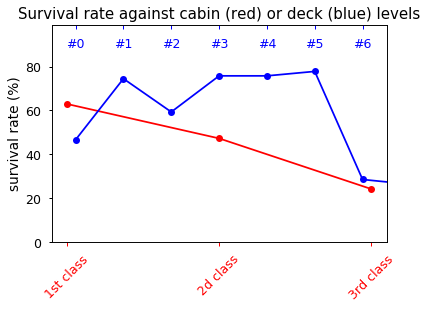

```python
# first axis
ax1 = plt.subplot(111)
ax1.set_title('Survival rate against cabin (red) or deck (blue) levels')
plt.xticks([1,2,3], ['1st class', '2d class', '3rd class'], rotation=45)
ax1.plot(100*titanic_df.groupby('Pclass')['Survived'].mean(), marker='o', color='r', label='vs. cabin class')
ax1.tick_params(axis='x', colors='red')
# twin axis
ax2 = ax1.twiny()
ax2.plot(100*titanic_df.groupby('deck')['Survived'].mean(), marker='o', color='b', label='vs. deck level')
ax2.set_xlim(-0.5,6.5)
ax2.set_xticklabels(['#%d'%l for l in ax2.get_xticks()], y=0.85)
ax2.tick_params(axis='x', colors='blue', direction='in')
# shared y axis
ax1.set_ylabel('survival rate (%)')
t = ax1.set_ylim(0,99)
```

### Survival rate vs. gender & age

'gender' field takes only two values which gives a natural grouping feature. On the contrary the age is a continuous variable, which prevents from easy grouping unless moving to age intervals. Let's do it:

```python
def to_age_interval(age):
    if age < 3: return 'baby'
    elif age < 16: return 'child'
    elif age < 50: return 'adult'
    elif age >= 50: return 'senior'
    else: return np.nan
```

```python
titanic_df['ageInterval'] = titanic_df['Age'].apply(to_age_interval)
```

Now let's group the dataset by age intervals and gender:

```python
titanic_df.groupby(('ageInterval', 'Sex'))['Survived'].describe()
```

| ageInterval | Sex | count | mean | std | min | 25% | 50% | 75% | max |
| --- | --- | --- | --- | --- | --- | --- | --- | --- | --- |
| adult | female | 196.0 | 0.760204 | 0.428052 | 0.0 | 1.0 | 1.0 | 1.0 | 1.0 |
|  | male | 361.0 | 0.180055 | 0.384767 | 0.0 | 0.0 | 0.0 | 0.0 | 1.0 |
| baby | female | 10.0 | 0.600000 | 0.516398 | 0.0 | 0.0 | 1.0 | 1.0 | 1.0 |
|  | male | 14.0 | 0.642857 | 0.497245 | 0.0 | 0.0 | 1.0 | 1.0 | 1.0 |
| child | female | 33.0 | 0.666667 | 0.478714 | 0.0 | 0.0 | 1.0 | 1.0 | 1.0 |
|  | male | 26.0 | 0.461538 | 0.508391 | 0.0 | 0.0 | 0.0 | 1.0 | 1.0 |
| senior | female | 22.0 | 0.909091 | 0.294245 | 0.0 | 1.0 | 1.0 | 1.0 | 1.0 |
|  | male | 52.0 | 0.134615 | 0.344642 | 0.0 | 0.0 | 0.0 | 0.0 | 1.0 |

In conclusion, this statistics confirms the well-known rule "Ladies and children first!" Fortunately, a higher rank in society did not give priority to safety boats.

### Cabin class vs. gender

It has been shown previously that both cabin class and passenger gender parameter did play a positive role for survival rate. How do they combine? Does it simply mean that more ladies travelled in first class? Let's focus on people above 16 years, interval which shows some discrepancies between male and female.

```python
adults_df = titanic_df[titanic_df['Age']>16.][['Survived', 'Pclass', 'Sex']]
```

Let's confirm that survival rate is (inversely) proportional to class level; the graph below shows a correlation factor between survival rate and cabin class around 0.4 in module (for adults):

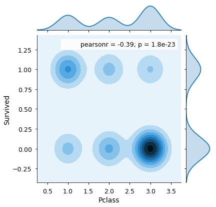

```python
ax = sb.jointplot(x='Pclass', y='Survived', data=adults_df, kind='kde')
```

Now let's compare it to the correlation between survival rate and gender which gives around 0.6 in module, see below:

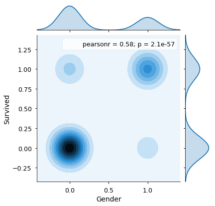

```python
# mapping sex string parameter to bool in order to ease statistics:
def gender_to_bool(sex):
    return 1 if sex=='female' else 0
adults_df['Gender'] = adults_df['Sex'].apply(gender_to_bool)
ax = sb.jointplot(x='Gender', y='Survived', data=adults_df, kind='kde')
```

Conclusion: previous statements based on average values comparison have been confirmed by this quick correlation analysis, based on Pearson's coefficient. The influence of gender seems even more important than cabin class level. Are both parameters linked?

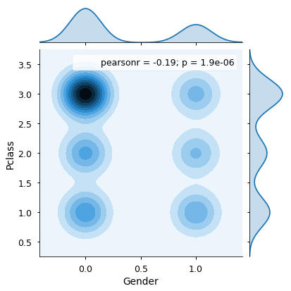

```python
ax = sb.jointplot(x='Gender', y='Pclass', data=adults_df, kind='kde')
```

Pearson's coefficient is not zero! Let's display this fact with figures:

```python
adults_df.groupby(('Pclass', 'Sex')).count()
```

| Pclass | Sex | Survived | Gender |
| --- | --- | --- | --- |
| 1 | female | 79 | 79 |
|  | male | 98 | 98 |
| 2 | female | 64 | 64 |
|  | male | 88 | 88 |
| 3 | female | 69 | 69 |
|  | male | 216 | 216 |

Confirmed! The influence of cabin class level shall be mitigated by the fact that gentlemen were over-represented in the third class, whereas ladies were almost equally reprensented among the three classes. Therefore, considering the rule 'Ladies and children first' induces an impact on the third-class survival rate which concern more men than ladies. Where did come all these men come from? Were they travelling alone?

### Men in third class?

Where did these 3rd class passengers come from?

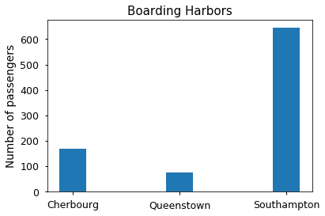

```python
ax = plt.subplot(111)
bar_index = np.arange(3)
ax.bar(bar_index, titanic_df.groupby('Embarked')['PassengerId'].count(), width=0.25)
ax.set_xticks(bar_index)
ax.set_xticklabels(('Cherbourg','Queenstown','Southampton'))
ax.set_ylabel('Number of passengers')
t = ax.set_title('Boarding Harbors')
```

The most represented town is Southampton. Are men and women equally distributed?

```python
titanic_df[titanic_df['Sex']=='male'].groupby('Embarked')['PassengerId'].count()
```

```
Embarked
C     95
Q     41
S    441
Name: PassengerId, dtype: int64
```

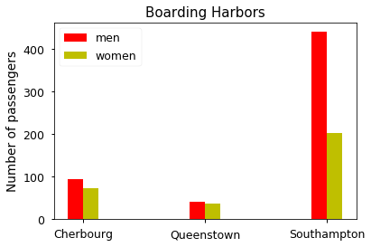

```python
ax=plt.subplot(111)
bar_index = np.arange(3)
bar_width = 0.125
y1 = titanic_df[titanic_df['Sex']=='male'].groupby('Embarked')['PassengerId'].count()
y2 = titanic_df[titanic_df['Sex']=='female'].groupby('Embarked')['PassengerId'].count()
rects1 = ax.bar(bar_index-0.5*bar_width, y1, width=bar_width, color='r', label='men')
rects2 = ax.bar(bar_index+0.5*bar_width, y2, width=bar_width, color='y', label='women')
ax.set_xticks(bar_index)
ax.set_xticklabels(('Cherbourg','Queenstown','Southampton'))
ax.set_ylabel('Number of passengers')
ax.set_title('Boarding Harbors')
l = ax.legend()
```

At Southampton harbor, a very big proportion of men embarked in third class. Now let's see if this unbalance is the same for the three cabin classes:

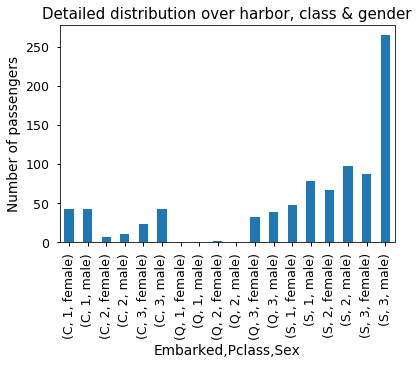

```python
#titanic_df.groupby(('Embarked','Pclass','Sex')).get_group(('C',2,'male'))['PassengerId'].count()
ds = titanic_df.groupby(('Embarked','Pclass','Sex'))['PassengerId'].count()
ax = ds.plot.bar()
ax.set_ylabel('Number of passengers')
t = ax.set_title('Detailed distribution over harbor, class & gender')
```

Some interesting findings and conclusions raise from the graph:

- It is the third class which hosted the big population of men embarked at Southampton
- Queenstown passengers were almost all hosted in third class

Conclusions:

- The low survival overall rate observed for third-class passengers is mainly related to the male population who embarked in Southampton
- It seems that there was not any rule of safety priority linked with social condition, fortunately!

### siblings, spouses, parents & children?

```python
titanic_df.groupby(('Survived'))[('SibSp', 'Parch')].describe()
```

| Survived | SibSp count | SibSp mean | SibSp std | SibSp min | SibSp 25% | SibSp 50% | SibSp 75% | SibSp max | Parch count | Parch mean | Parch std | Parch min | Parch 25% | Parch 50% | Parch 75% | Parch max |
| --- | --- | --- | --- | --- | --- | --- | --- | --- | --- | --- | --- | --- | --- | --- | --- | --- |
| 0 | 549.0 | 0.553734 | 1.288399 | 0.0 | 0.0 | 0.0 | 1.0 | 8.0 | 549.0 | 0.329690 | 0.823166 | 0.0 | 0.0 | 0.0 | 0.0 | 6.0 |
| 1 | 342.0 | 0.473684 | 0.708688 | 0.0 | 0.0 | 0.0 | 1.0 | 4.0 | 342.0 | 0.464912 | 0.771712 | 0.0 | 0.0 | 0.0 | 1.0 | 5.0 |

At first sight, no trend seems to link survival rate and number of persons per family. Some further investigation may reveal correlations...

## Data prediction

Can we predict the survival propability for the two missing ladies if they did embark?

```python
missing_bools = True ^ ((titanic_df['Embarked'] == 'Q') | (titanic_df['Embarked'] == 'C') | (titanic_df['Embarked'] == 'S'))
titanic_df[missing_bools][['Name', 'Age', 'ageInterval']]
```

|  | Name | Age | ageInterval |
| --- | --- | --- | --- |
| 61 | Icard, Miss. Amelie | 38.0 | adult |
| 829 | Stone, Mrs. George Nelson (Martha Evelyn) | 62.0 | senior |

Let's base our prediction on factors age and gender:

```python
ladies_df = titanic_df.groupby('Sex').get_group(('female'))
ladies_df.groupby('ageInterval')['Survived'].describe()
```

| ageInterval | count | mean | std | min | 25% | 50% | 75% | max |
| --- | --- | --- | --- | --- | --- | --- | --- | --- |
| adult | 196.0 | 0.760204 | 0.428052 | 0.0 | 1.0 | 1.0 | 1.0 | 1.0 |
| baby | 10.0 | 0.600000 | 0.516398 | 0.0 | 0.0 | 1.0 | 1.0 | 1.0 |
| child | 33.0 | 0.666667 | 0.478714 | 0.0 | 0.0 | 1.0 | 1.0 | 1.0 |
| senior | 22.0 | 0.909091 | 0.294245 | 0.0 | 1.0 | 1.0 | 1.0 | 1.0 |

Miss Amelie Icard, as an adult, got a survival probability of 76% whereas Mrs Martha Stone, as a senior, would have likely survived, with a probability of 91%!

# Conclusion

The Titanic passengers dataset taught us that on the sea, the rule for choosing passengers to be saved first is the classical one: 'Ladies and children first!'. Unlike the Costa Concordia captain, the Titanic crew did respect this basic safety rule.

Deeper analysis could nevertheless be performed to figure out what role could have played the family structure during rescue...